# Análisis exploratorio: en_vm_canalX

Alejandro Bedoya - Sebastián Agudelo - Mateo Espinal - Juan Fernando Patiño - Estefanía Echeverry

Junio - 2021

# 1. Pasos previos al análisis

## 1.1. Se cargan las librerías necesarias

```r
library(dplyr)
library(knitr)
library(kableExtra)
library(ggplot2)
library(ggcorrplot)
library(scales)
library(formattable)
options(scipen = 999)
```

## 1.2. Lectura de la base de datos

```r
#Se carga la base de datos
datos_originales <- read.csv("../datos/base_trabajo_segmentacion.csv",
                             sep = ";")

#Se imprime la cabecera
kable(head(datos_originales), "html", align = "c") %>%
    kable_paper("hover", full_width = F) %>%
    row_spec(0, background = "#327CCF", color = "white")%>%
    scroll_box(width = "100%") %>%
    kable_styling(bootstrap_options = c("hover", "condensed"))
```

| nit | en_vm_canal1 | en_vm_canal2 | en_vm_canal3 | en_vm_canal4 | en_vm_canal5 | en_vm_canal6 | en_vm_canal7 | en_vm_canal8 | en_vm_canal9 | en_vm_canal10 | en_vm_otros | en_tx_canal1 | en_tx_canal2 | en_tx_canal3 | en_tx_canal4 | en_tx_canal5 | en_tx_canal6 | en_tx_canal7 | en_tx_canal8 | en_tx_canal9 | en_tx_canal10 | en_tx_otros | sal_vm_canal5 | sal_vm_canal2 | sal_vm_canal8 | sal_vm_otros | sal_tx_canal5 | sal_tx_canal2 | sal_tx_canal8 | … |
| --- | --- | --- | --- | --- | --- | --- | --- | --- | --- | --- | --- | --- | --- | --- | --- | --- | --- | --- | --- | --- | --- | --- | --- | --- | --- | --- | --- | --- | --- | --- |
| C4936394968152386565 | 0 | 0 | 0 | 0 | 0 | 0 | 0 | 0 | 0 | 0 | 0 | 0.000000 | 0.000000 | 0.000000 | 0.00000 | 0.000000 | 0.00 | 0.00 | 0.0 | 0 | 0 | 0 | 0 | 0 | 0 | 0 | 0.000000 | 0.00000 | 0 | … |
| C-8615176103348111575 | 0 | 0 | 0 | 0 | 0 | 0 | 0 | 0 | 0 | 0 | 0 | 0.000000 | 0.000000 | 0.000000 | 0.00000 | 0.000000 | 0.00 | 0.00 | 0.0 | 0 | 0 | 0 | 0 | 0 | 0 | 0 | 0.000000 | 0.00000 | 0 | … |
| C2364605246729357060 | 250927493 | 54160892 | 5122152 | 41852510 | 413614315 | 1663236 | 2106847525 | 0 | 0 | 0 | 0 | 24.416667 | 11.916667 | 3.333333 | 237.83333 | 2.545454 | 5.40 | 8.25 | 0.0 | 0 | 0 | 0 | 413614315 | 2265361194 | 0 | 0 | 2.545454 | 613.08333 | 0 | … |
| C7393816976826597531 | 39402360 | 96468998 | 8226710 | 0 | 0 | 7072802 | 0 | 9000000 | 0 | 0 | 0 | 14.416667 | 13.833333 | 4.600000 | 0.00000 | 0.000000 | 2.80 | 0.00 | 1.0 | 0 | 0 | 0 | 0 | 60558440 | 0 | 0 | 0.000000 | 10.33333 | 0 | … |
| C872645851723947566 | 337432319 | 234217927 | 105344054 | 15755287 | 0 | 23671840 | 0 | 3600962 | 3727299 | 0 | 0 | 153.583333 | 42.250000 | 102.416667 | 49.33333 | 0.000000 | 18.00 | 0.00 | 2.2 | 4 | 0 | 0 | 0 | 0 | 0 | 622080714 | 0.000000 | 0.00000 | 0 | … |
| C-3870380727390720970 | 33629514 | 42883291 | 1348792 | 0 | 0 | 3828360 | 0 | 0 | 687244 | 0 | 0 | 7.416667 | 8.833333 | 1.000000 | 0.00000 | 0.000000 | 1.25 | 0.00 | 0.0 | 1 | 0 | 0 | 0 | 1960611436 | 0 | 0 | 0.000000 | 90.00000 | 0 | … |

## 1.3. Creación de funciones necesarias

**Función encargada de presentar los resúmenes numéricos**

```r
#Se define la función para presentar los resumenes numéricos
resumen <- function(columna){
    #Se usa la función summary para encontrar los resumenes
    summary_canal <- summary(columna)

    #Se convierte a array y se transpone el resumen numérico
    summary_canal <- t(summary_canal)

    #Se transforman las cantidades a formato de moneda
    summary_canal <- t(apply(summary_canal, 2, dollar))

    #Se calcula la cantidad de ceros de la variable
    ceros <- sum(columna == 0)

    #Se calcula la proporción de ceros para cada variable
    prop_ceros <- ceros/length(columna)

    #Se convierte la proporción de ceros a escala de porcentaje
    prop_ceros <- round(prop_ceros,4)*100

    #Se añade el simbolo de porcentaje a la proporción de eros
    prop_ceros <- paste0(prop_ceros,"%")

    #Se concatena el resumen numerico con la cantidad y la proporción de ceros
    summary_canal <- cbind(summary_canal, ceros, prop_ceros)

    #Se crean los nombres en español para los resumenes
    nombres_resumen <- c("Mínimo", "Q1", "Mediana", "Media", "Q3",
                         "Máximo", "Ceros", "Proporcion ceros")

    #Se estiliza el resumen con la función kable
    kable(summary_canal, col.names = nombres_resumen, align = "c",  "html") %>%
        #Se utiliza el tema kable_papper
        kable_paper("hover", full_width = TRUE) %>%
        kable_styling(bootstrap_options = c("hover", "condensed"),
                      font_size = 16) %>%
        row_spec(0, background = "#327CCF", color = "white")
}
```

**Función encargada de realizar los histogramas**

```r
#Se crea la función para dibujar los gráficos
crear_grafico <- function(datos, columna, bins=300, numero_columna){

    columna = enquo(columna)

    #Se crea el histograma
    grafico <- ggplot(datos, aes(x = !!columna)) +
        geom_histogram(bins = bins, fill="#327CCF", alpha = 0.4, col = "Black")+
        #Se añade la etiqueta del eje x
        xlab(
            paste("Valor del ticket promedio de entrada por el canal",
                  numero_columna)
        ) +
        #Se añade la etiqueta del eje y
        ylab("Frecuencia") +
        #Se añade la etiqueta del titulo
        ggtitle(
            paste(
              "Histograma del valor del ticket promedio de entrada por el canal",
              numero_columna)
        ) +
        theme_bw()
        #Se centra el titulo
        theme(plot.title = element_text(hjust = 0.5))

    return(grafico)
}
```

# 2. Análisis de las variables `en_vm_canalx`

## 2.1. `en_vm_canal1`

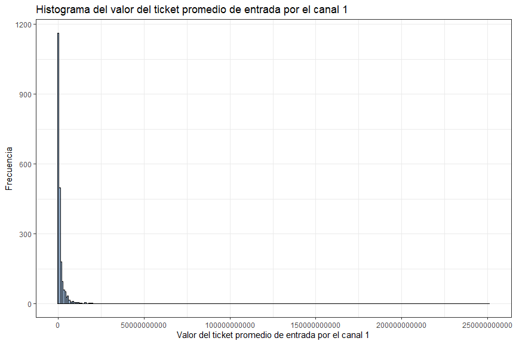

```r
crear_grafico(datos_originales, en_vm_canal1, bins = 320, numero_columna = 1)
```

```r
resumen(datos_originales$en_vm_canal1)
```

| Mínimo | Q1 | Mediana | Media | Q3 | Máximo | Ceros | Proporcion ceros |
| --- | --- | --- | --- | --- | --- | --- | --- |
| $0 | $51,375,043 | $348,671,476 | $1,853,339,862 | $1,229,572,057 | $251,092,000,000 | 202 | 9.05% |

Del histograma se resalta que la distribución del valor del ticket promedio de entrada por el canal 1 se encuentra altamente sesgada a la derecha, lo cual se evidencia también en el resumen numérico donde la mediana ($348,671,476) se encuentra en la escala de cientos de millones, mientras que la media ($1,853,339,862) se encuentra en la escala de miles de millones, superando no solo el valor de la medida anterior, sino también el del cuartil 3 ($1,229,572,057), reflejando con esto que los valores máximos se encuentran en una escala muy alejada de la mayoría de los datos del canal.

Se destaca además que la proporción de entradas en cero (9.05%) del canal es baja, lo cual indica que es altamente usado y da la sensación de tener pocas restricciones y ser de fácil acceso.

## 2.2. `en_vm_canal2`

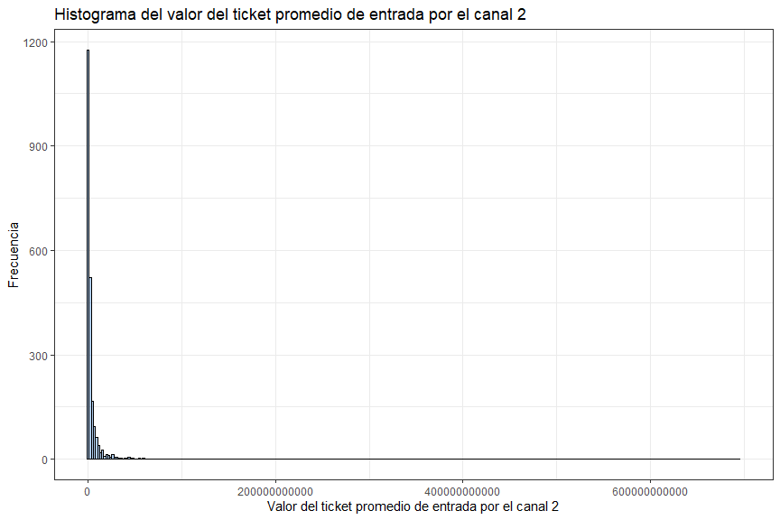

```r
crear_grafico(datos_originales, en_vm_canal2, bins = 320, numero_columna = 2)
```

```r
resumen(datos_originales$en_vm_canal2)
```

| Mínimo | Q1 | Mediana | Media | Q3 | Máximo | Ceros | Proporcion ceros |
| --- | --- | --- | --- | --- | --- | --- | --- |
| $0 | $224,638,525 | $961,172,220 | $5,073,029,898 | $3,113,984,333 | $695,285,000,000 | 186 | 8.33% |

Del histograma se resalta que la distribución del valor del ticket promedio de entrada por el canal 2 se encuentra altamente sesgada a la derecha, similar a lo evidenciado en el canal 1 pero en una escala monetaria mayor, donde la mediana ($961,172,220) es cercana a los mil millones, valor que se encuentra muy por debajo de la media ($5,073,029,898), la cual a su vez es mayor al cuartil 3 ($3,113,984,333), exhibiendo la presencia de valores máximos demasiado grandes.

Se destaca además que la proporción de entradas en cero (8.33%) es mas baja que en el canal 1, lo cual nos indica que es altamente usado y da la sensación de tener pocas restricciones y ser de fácil acceso. Se enfatiza que los valores de todas las medidas de resumen son mayores a las del canal anterior, dando la sensación de ser típicamente usado para transacciones mas altas.

## 2.3. `en_vm_canal3`

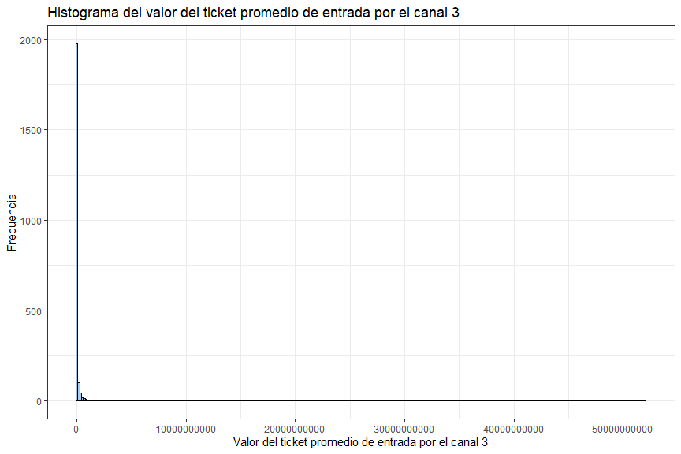

```r
crear_grafico(datos_originales, en_vm_canal3, bins = 320, numero_columna = 3)
```

```r
resumen(datos_originales$en_vm_canal3)
```

| Mínimo | Q1 | Mediana | Media | Q3 | Máximo | Ceros | Proporcion ceros |
| --- | --- | --- | --- | --- | --- | --- | --- |
| $0 | $0 | $1,262,784 | $198,004,356 | $8,258,949 | $52,076,541,969 | 705 | 31.57% |

Del histograma se resalta que la distribución del valor del ticket promedio de entrada por el canal 3 se encuentra altamente sesgada a la derecha, similar a lo evidenciado para los dos canales anteriores pero en una escala monetaria menor a ambos, donde la mediana ($1,262,784) está en la escala de millones, valor que se encuentra muy por debajo de la media ($198,004,356), la cual a su vez es en gran medida mayor al cuartil 3 ($8,258,949), exhibiendo la presencia de valores máximos demasiado grandes.

Se destaca además que la proporción de entradas en cero (31.57%) es mas alta que lo visto para los canales anteriores, lo cual nos indica que es menos usado y da la sensación de ser más restrictivo o no ser tan accesible. Se enfatiza que los valores de todas las medidas de resumen son menores a las de los canales anteriores, dando la sensación de ser típicamente usado para transacciones mas bajas.

## 2.4. `en_vm_canal4`

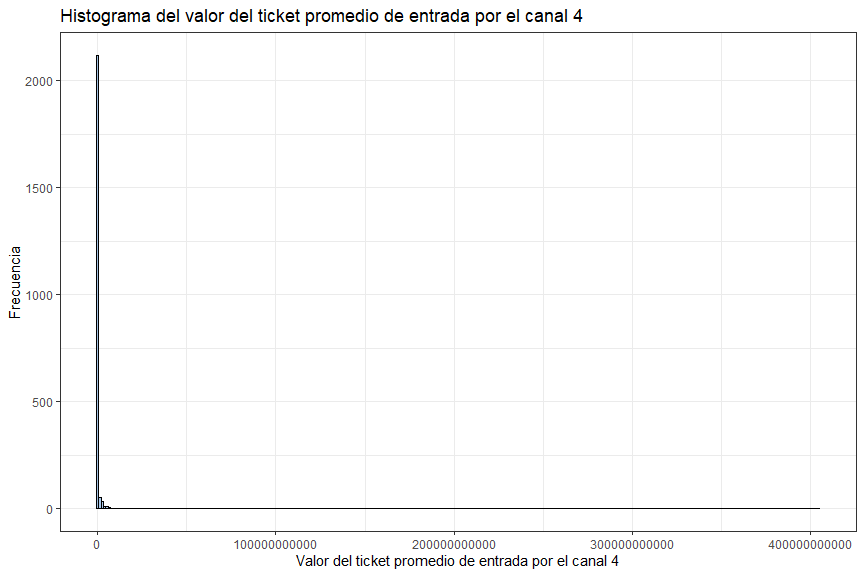

```r
crear_grafico(datos_originales, en_vm_canal4, bins = 320, numero_columna = 4)
```

```r
resumen(datos_originales$en_vm_canal4)
```

| Mínimo | Q1 | Mediana | Media | Q3 | Máximo | Ceros | Proporcion ceros |
| --- | --- | --- | --- | --- | --- | --- | --- |
| $0 | $0 | $0 | $436,748,915 | $3,714,011 | $405,096,000,000 | 1591 | 71.25% |

Del histograma se resalta que la distribución del valor del ticket promedio de entrada por el canal 4 se encuentra altamente sesgada a la derecha, presentando la particularidad de que la mediana ($0) es cero, la media ($436,748,915) se encuentra en la escala de cientos de millones, valor mayor al canal anterior pero menor a los canales 1 y 2, la cual a su vez es en gran medida mayor al cuartil 3 ($3,714,011), exhibiendo la presencia de muchos valores en cero y máximos muy alejados del resto de los datos, en particular se resalta que el máximo de este canal es mayor que el de los canales 1 y 3, los cuales son aparentemente mas usados.

Se destaca además que la proporción de entradas en cero (71.25%) es mucho mas alta que lo visto para los canales anteriores, dando la sensación de ser poco usado tal vez por ser más restrictivo, poco accesible o exclusivo.

## 2.5. `en_vm_canal5`

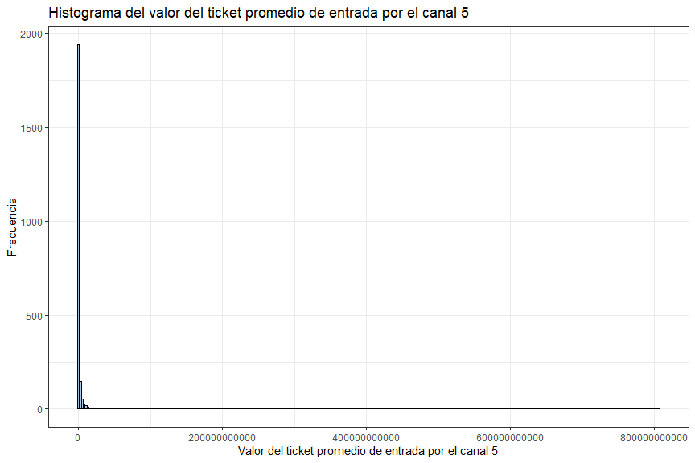

```r
crear_grafico(datos_originales, en_vm_canal5, bins = 320, numero_columna = 5)
```

```r
resumen(datos_originales$en_vm_canal5)
```

| Mínimo | Q1 | Mediana | Media | Q3 | Máximo | Ceros | Proporcion ceros |
| --- | --- | --- | --- | --- | --- | --- | --- |
| $0 | $0 | $4,216,583 | $2,120,246,761 | $300,000,000 | $806,965,000,000 | 1032 | 46.22% |

Se resalta además que la proporción de entradas en cero (46.22%) es mas alta que la de los tres primeros canales e inferior al canal 4, todo lo anterior da la sensación de que el canal 5 está dedicado principalmente a transacciones de entrada que tienden a tener valores elevados.

## 2.6. `en_vm_canal6`

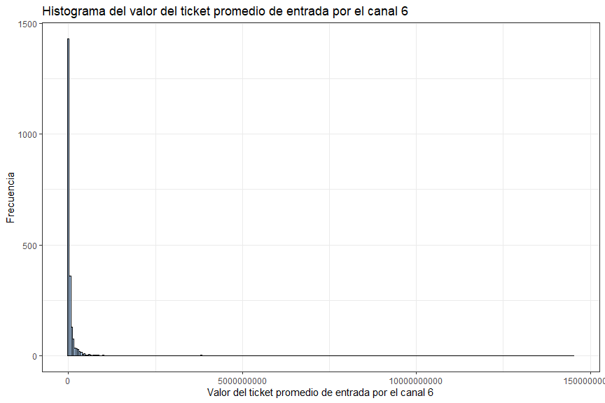

```r
crear_grafico(datos_originales, en_vm_canal6, bins = 320, numero_columna = 6)
```

```r
resumen(datos_originales$en_vm_canal6)
```

| Mínimo | Q1 | Mediana | Media | Q3 | Máximo | Ceros | Proporcion ceros |
| --- | --- | --- | --- | --- | --- | --- | --- |
| $0 | $598,340 | $9,021,177 | $123,493,933 | $47,119,545 | $14,523,636,565 | 426 | 19.08% |

Del histograma se resalta que la distribución del valor del ticket promedio de entrada por el canal 6 se encuentra altamente sesgada a la derecha, con una mediana ($9,021,177) en la escala de millones, menor a la media ($123,493,933) que se encuentra en la escala de cientos de millones y no está tan alejada al cuartil 3 ($47,119,545), lo cual se refleja en la presencia de valores máximos no tan altos como se ha visto previamente.

Se destaca además que la proporción de entradas en cero (19.08%) no es tan alta como en los tres canales anteriores, el canal 6 tiene una apariencia bastante promedio, de no ser muy restrictivo y de fácil acceso.

## 2.7. `en_vm_canal7`

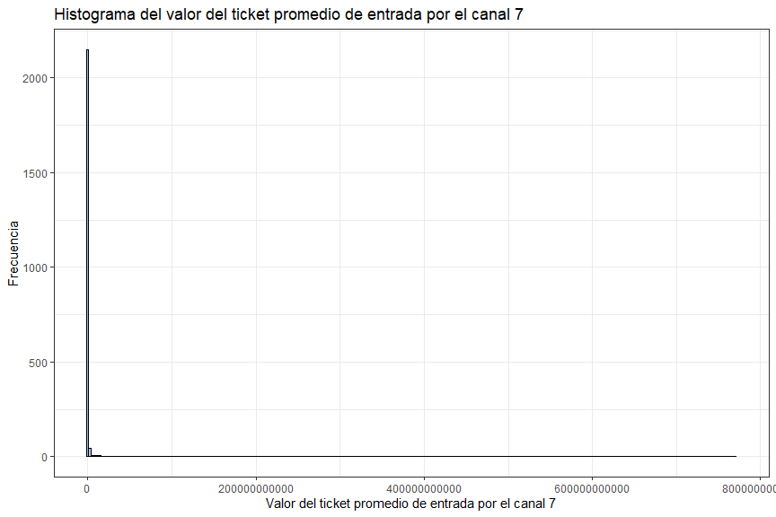

```r
crear_grafico(datos_originales, en_vm_canal7, bins = 320, numero_columna = 7)
```

```r
resumen(datos_originales$en_vm_canal7)
```

| Mínimo | Q1 | Mediana | Media | Q3 | Máximo | Ceros | Proporcion ceros |
| --- | --- | --- | --- | --- | --- | --- | --- |
| $0 | $0 | $0 | $1,066,323,115 | $0 | $770,542,000,000 | 2028 | 90.82% |

Del histograma se resalta que la distribución del valor del ticket promedio de entrada por el canal 7 se encuentra altamente sesgada a la derecha, con una mediana ($0) en cero, compartiendo el mismo valor con el cuartil 3 ($0), indicando en primera instancia que el canal es poco usado en comparación con los anteriores, sin embargo, la media ($1,066,323,115) presenta un valor sumamente alto, en la escala de miles de millones, lo cual se explica por la presencia de valores máximos muy altos, en particular este canal presenta el segundo máximo mas alto de las variables de este tipo.

Se destaca además que la proporción de entradas en cero (90.82%) es la mas alta de esta categoría, dando la sensación de ser un canal poco usado tal vez por ser muy restrictivo, poco accesible, exclusivo o destinado a clientes especificos.

## 2.8. `en_vm_canal8`

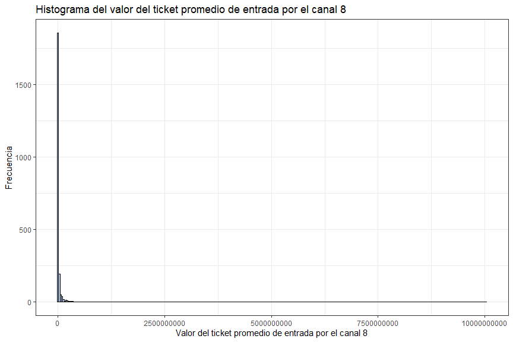

```r
crear_grafico(datos_originales, en_vm_canal8, bins = 320, numero_columna = 8)
```

```r
resumen(datos_originales$en_vm_canal8)
```

| Mínimo | Q1 | Mediana | Media | Q3 | Máximo | Ceros | Proporcion ceros |
| --- | --- | --- | --- | --- | --- | --- | --- |
| $0 | $0 | $1,908,552 | $28,877,321 | $7,916,394 | $10,038,465,888 | 723 | 32.38% |

Del histograma se resalta que la distribución del valor del ticket promedio de entrada por el canal 8 se encuentra altamente sesgada a la derecha, con un comportamiento muy similar al canal 3, pero con magnitudes monetarias menores, donde la mediana ($1,908,552) está en la escala de millones, valor que se encuentra por debajo de la media ($28,877,321), la cual a su vez mayor al cuartil 3 ($7,916,394), exhibiendo la presencia de valores máximos grandes, pero no tan alejados como lo evidenciado en las variables anteriores.

Se destaca además que la proporción de entradas en cero (32.38%) es levemente mayor a la del canal 3, dando la sensación de ser de un uso moderadamente bajo, tal vez un poco restrictivo o levemente limitado en accesibilidad, además de aparentemente ser usado para transacciones de valores monetarios moderadamente bajos.

## 2.9. `en_vm_canal9`

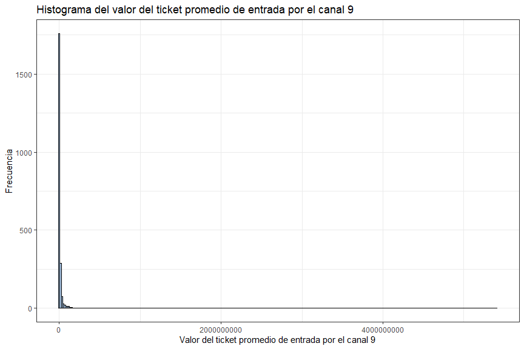

```r
crear_grafico(datos_originales, en_vm_canal9, bins = 320, numero_columna = 9)
```

```r
resumen(datos_originales$en_vm_canal9)
```

| Mínimo | Q1 | Mediana | Media | Q3 | Máximo | Ceros | Proporcion ceros |
| --- | --- | --- | --- | --- | --- | --- | --- |
| $0 | $0 | $1,509,495 | $12,474,334 | $7,011,999 | $5,408,476,569 | 727 | 32.56% |

Del histograma se resalta que la distribución del valor del ticket promedio de entrada por el canal 9 se encuentra altamente sesgada a la derecha, con un comportamiento muy similar a los canales 3 y 8, pero con magnitudes monetarias menores, donde la mediana ($1,509,495) está en la escala de millones, valor que se encuentra por debajo de la media ($12,474,334), la cual a su vez es levemente mayor al cuartil 3 ($7,011,999), exhibiendo la presencia de valores máximos moderadamente altos.

Se destaca además que la proporción de entradas en cero (32.56%) es levemente mayor a la del canal 8 y por ende mayor a la del canal 3, dando una sensación similar a la del canal anterior, con un uso moderadamente bajo, tal vez un poco restrictivo o levemente limitado en accesibilidad, además de aparentemente ser usado para transacciones de valores monetarios moderadamente bajos.

## 2.10. `en_vm_canal10`

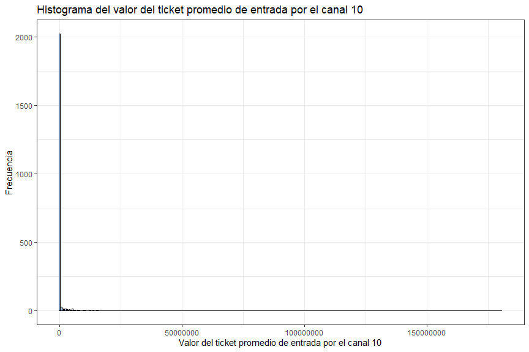

```r
crear_grafico(datos_originales, en_vm_canal10, bins = 320, numero_columna = 10)
```

```r
resumen(datos_originales$en_vm_canal10)
```

| Mínimo | Q1 | Mediana | Media | Q3 | Máximo | Ceros | Proporcion ceros |
| --- | --- | --- | --- | --- | --- | --- | --- |
| $0 | $0 | $0 | $986,298 | $0 | $180,475,245 | 1998 | 89.48% |

Del histograma se resalta que la distribución del valor del ticket promedio de entrada por el canal 10 se encuentra altamente sesgada a la derecha, compartiendo un comportamiento muy similar al canal 7 pero con magnitudes monetarias sustancialmente más bajas, donde la mediana ($0) toma el valor de cero, al igual que el cuartil 3 ($0), indicando en primera instancia que el canal es poco usado, donde la media ($986,298) presenta un valor sumamente bajo en comparación con los demás canales, situandose en la escala de los cientos de miles y rozando el millón, lo cual se explica por la presencia de valores máximos bajos, en particular este canal presenta el máximo mas bajo de las variables de este tipo.

Se destaca además que la proporción de entradas en cero (89.48%) es muy cercana a la del canal 7, dando la sensación de ser poco usado tal vez por ser muy restrictivo, poco accesible, exclusivo o destinado a clientes específicos, y usado típicamente para transacciones de magnitudes muy bajas.

## 2.11. `en_vm_otros`

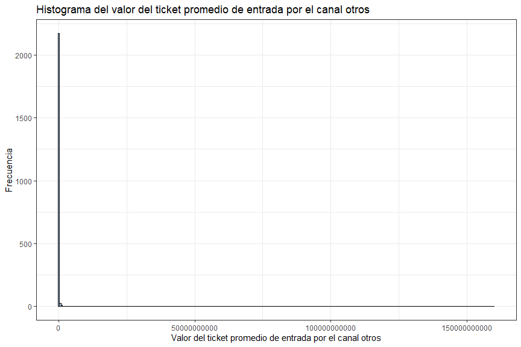

```r
crear_grafico(datos_originales, en_vm_otros, bins = 320, numero_columna = "otros")
```

```r
resumen(datos_originales$en_vm_otros)
```

| Mínimo | Q1 | Mediana | Media | Q3 | Máximo | Ceros | Proporcion ceros |
| --- | --- | --- | --- | --- | --- | --- | --- |
| $0 | $0 | $0 | $257,123,409 | $0 | $160,039,000,000 | 1829 | 81.91% |

Del histograma se resalta que la distribución del valor del ticket promedio de entrada por el canal otros se encuentra altamente sesgada a la derecha, la cual al igual que la variable anterior comparte un comportamiento muy similar al canal 7 pero con magnitudes monetarias mayores a las del canal 10, donde la mediana ($0) toma el valor de cero, al igual que el cuartil 3 ($0), indicando en primera instancia que el canal es poco usado, donde la media ($257,123,409) presenta un valor en la escala de los cientos de de millones, lo cual se explica por la presencia de valores máximos medianamente altos.

Se destaca además que la proporción de entradas en cero (81.91%) es muy alta, dando la sensación de ser poco usado tal vez por ser restrictivo, poco accesible, exclusivo o destinado a clientes específicos.

# 3. Tabla general de resumenes numéricos:

```r
#Se seleccionan las columnas de tipo en_vm
datos_en_vm <- datos_originales %>% select(contains("en_vm"))

#Se aplica la función summary a cada columna
resumen_general <- t(apply(datos_en_vm, 2, function(x){summary(x)}))

#Se convierte el resulado anterior a data frame
resumen_general <- as.data.frame(resumen_general)

#Se convierten las cantidades a formato de moneda
resumen_general <- apply(resumen_general, 2, dollar)

#Se calcula la cantidad de ceros para cada variable
cantidad_ceros <- apply(datos_en_vm, 2, function(x){sum(x==0)})

#Se calcula la proporción de ceros para cada variable
proporcion_ceros <- apply(datos_en_vm,
                          2,
                          function(x){
                            p_ceros <- sum(x==0)/length(x)
                            p_ceros <- round(p_ceros ,4)*100
                            paste0(p_ceros, "%")
                            }
                          )

#Se concatene el resumen con la cantidad y la proporción de ceros
resumen_general <- cbind(resumen_general, cantidad_ceros, proporcion_ceros)

#Se crean las etiquetas de la cabecera para los resumenes
nombres_resumen <- c(
  "Mínimo", "Q1", "Mediana", "Media", "Q3", "Máximo", "Ceros", "Proporcion ceros"
  )

#Se muestra la tabla estilizada con la función kable
kable(resumen_general, col.names = nombres_resumen, align = "r") %>%
    kable_paper("hover", full_width = TRUE) %>%
    kable_styling(bootstrap_options = c("hover", "condensed"), font_size = 14) %>%
    row_spec(0, background = "#327CCF", color = "white")
```

|  | Mínimo | Q1 | Mediana | Media | Q3 | Máximo | Ceros | Proporcion ceros |
| --- | --- | --- | --- | --- | --- | --- | --- | --- |
| en_vm_canal1 | $0 | $51,375,043 | $348,671,476 | $1,853,339,862 | $1,229,572,057 | $251,092,000,000 | 202 | 9.05% |
| en_vm_canal2 | $0 | $224,638,525 | $961,172,220 | $5,073,029,898 | $3,113,984,333 | $695,285,000,000 | 186 | 8.33% |
| en_vm_canal3 | $0 | $0 | $1,262,784 | $198,004,356 | $8,258,949 | $52,076,541,969 | 705 | 31.57% |
| en_vm_canal4 | $0 | $0 | $0 | $436,748,915 | $3,714,011 | $405,096,000,000 | 1591 | 71.25% |
| en_vm_canal5 | $0 | $0 | $4,216,583 | $2,120,246,761 | $300,000,000 | $806,965,000,000 | 1032 | 46.22% |
| en_vm_canal6 | $0 | $598,340 | $9,021,177 | $123,493,933 | $47,119,545 | $14,523,636,565 | 426 | 19.08% |
| en_vm_canal7 | $0 | $0 | $0 | $1,066,323,115 | $0 | $770,542,000,000 | 2028 | 90.82% |
| en_vm_canal8 | $0 | $0 | $1,908,552 | $28,877,321 | $7,916,394 | $10,038,465,888 | 723 | 32.38% |
| en_vm_canal9 | $0 | $0 | $1,509,495 | $12,474,334 | $7,011,999 | $5,408,476,569 | 727 | 32.56% |
| en_vm_canal10 | $0 | $0 | $0 | $986,298 | $0 | $180,475,245 | 1998 | 89.48% |
| en_vm_otros | $0 | $0 | $0 | $257,123,409 | $0 | $160,039,000,000 | 1829 | 81.91% |

# 4. Correlación entre las variables

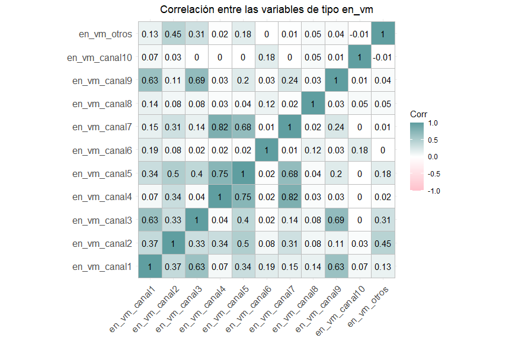

```r
#Se calulan las correlaciones entre las variables
correlaciones <- cor(datos_en_vm)

#Se muestra el gráfico de correlación
ggcorrplot(correlaciones, lab = TRUE, colors = c("pink",
                                                 "white",
                                                 "cadetblue")
)+
  #Se añade el titulo del gráfico
  ggtitle("Correlación entre las variables de tipo en_vm")+
  #Se centra el titulo
  theme(plot.title = element_text(hjust = 0.5))
```